# ESM 206 Assignment 4 Report

Qusai Bhaijeewala and Ruiheng Jin

11/12/2019

## INTRODUCTION

In 2012, the Santa Barbara Coastal Long Term Ecological Research program (SBC LTER) started collecting data on spiny lobster to determine if their populations and sizes were affected by fishing intensity. The purpose of this report is to determine the changes in lobster abundance and lobster size from 2012 to 2018 from five sites in Santa Barbara County. The five sites are Arroyo Quemado, Carpinteria, Isla Vista, Mohawk, Naples. Special attention will be given to the two Marine Protected Area (MPA) of Naples and Isla Vista. Additionally, this report will compare average lobster size in millimeters for MPA and NON MPA sites in the years 2012 and 2018.These finding will pave the way for further analysis that determines the cause of certain trends in lobster population and size changes.

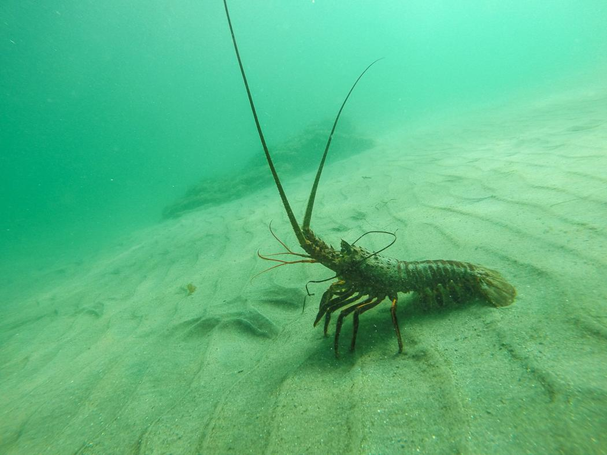

Figure 1. California Spiny Lobster Credit: [Vice.com](https://www.vice.com/en_us/article/gvk5kq/why-we-dont-eat-california-spiny-lobsters-even-though-they-taste-better)

## DATA AND METHODS

The data used in this report was collected by researchers from the Santa Barbara Coastal Long Term Ecological Research program (SBC LTER). The data includes observations of California spiny lobsters at five locations, two of which are Marine Protected Area (MPA). Three variables are studied in this report: year of observation, site of observation, size of lobster (mm). Two-sample, two-sided, unpaired tests (α = 0.05) and cohen’s d are performed for comparisons of mean lobster sizes between MPA sites and non-MPA sites, and between 2012 and 2018. Data analysis is performed using RStudio (Version 1.2.1335).

## RESULTS

### RESULTS A

#### **CHANGES IN ANNUAL LOBSTER ABUNDANCE AT FIVE SITES**

Isla Vista has the most noticeable increase in lobster abundance from 2012 to 2018. Additionally, further analysis is needed to explain the sudden spike in lobster abundance in Isla Vista after 2016. Naples and Mohawk have similar increasing trends, although Naples experienced an increase between 2017 and 2018; while Mohawk, a decrease. Carpinteria experienced a large increase between 2016 and 2017, but also a large decrease the following year. The abundance at Arroyo Quemado remained low throughout the 2012-2018 period (Figure 2).

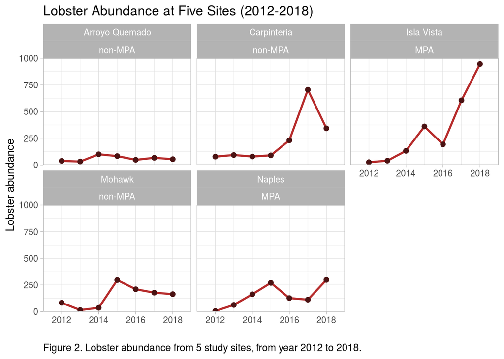

### RESULTS B

#### **SHIFTS IN LOBSTER SIZE DISTRIBUTION FROM 2012 TO 2018**

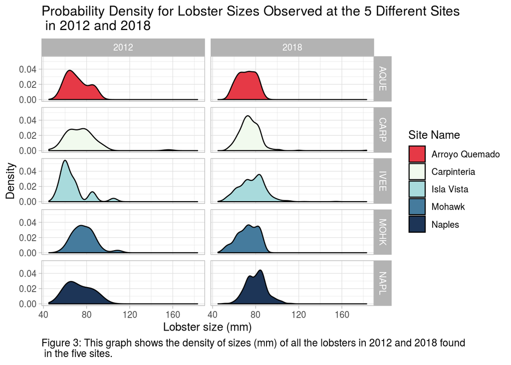

### RESULTS C

#### **COMPARING MEAN LOBSTER SIZES AT MPA VS NON-MPA SITES IN 2012 AND 2018**

Table 1. Mean lobster size, standard deviation and sample size for MPA and non-MPA sites in 2012 and 2018.

| LOBSTER SIZE METRICS MPA Status | LOBSTER SIZE METRICS Year | LOBSTER SIZE METRICS Mean Lobster Size (mm) | LOBSTER SIZE METRICS Standard Deviation | LOBSTER SIZE METRICS Sample Size |
| --- | --- | --- | --- | --- |
| non-MPA | 2012 | 74.92462 | 12.41412 | 199 |
| non-MPA | 2018 | 73.61996 | 10.09438 | 561 |
| MPA | 2012 | 67.37500 | 12.15425 | 32 |
| MPA | 2018 | 77.56672 | 11.70341 | 1244 |

#### 2) Mean lobster size at non-MPA sites in 2012 and 2018

- Mean lobster sizes at non-MPA sites do not differ significantly between 2012 and 2018 (t(296.01) = 1.33, p = 0.1831).
- The 95% confidence interval is (-0.62, 3.23).
- The effect size is negligible (Cohen’s d = 0.121).
- Mean lobster sizes at non-MPA sites in 2012 and 2018 are 74.92, 73.62 mm, respectively. The difference in means is 1.3 mm.

#### 3) Mean lobster size at MPA and non-MPA sites in 2012

- Mean lobster sizes differ significantly between MPA and non-MPA sites in 2012 (t(42.09) = -3.25, p = 0.0023).
- The 95% confidence interval is (-12.23, -2.86).
- The effect size is medium (Cohen’s d = -0.61).
- In 2012, mean lobster sizes at MPA and non-MPA sites are 67.38, 74.92 mm, respectively. The difference in means is -7.55 mm.

## REFERENCE

- Hadley Wickham (2017). tidyverse: Easily Install and Load the ‘Tidyverse’. R package version 1.2.1. https://CRAN.R-project.org/package=tidyverse
- Hao Zhu (2019). kableExtra: Construct Complex Table with ‘kable’ and Pipe Syntax. R package version 1.1.0. https://CRAN.R-project.org/package=kableExtra
- Reed D. 2019. SBC LTER: Reef: Abundance, size and fishing effort for California Spiny Lobster ( Panulirus interruptus ), ongoing since 2012. Environmental Data Initiative. https://doi.org/10.6073/pasta/a593a675d644fdefb736750b291579a0 . Dataset accessed 11/12/2019.
- Sam Firke (2019). janitor: Simple Tools for Examining and Cleaning Dirty Data. R package version 1.2.0. https://CRAN.R-project.org/package=janitor
- Torchiano M (2019). *effsize: Efficient Effect Size Computation*. doi: 10.5281/zenodo.1480624 (URL: https://doi.org/10.5281/zenodo.1480624), R package version 0.7.6, <URL: https://CRAN.R-project.org/package=effsize>.